# TASK-1

### Task-1 : Predict the percentage of marks of an student based on the number of study hours.

#### We will use the following packagesto build the model:

- Pandas Dataframe to read the csv file and get the data in a tabular form.
- From matplotlib we import pyplot to plot and get insights about the data.
- Before building the model the data will be split into test and train.
- From sklearn linear model we LinearRegression Package to go ahea and build our model.
- Use the model to predict the marks which can obtained by a student based on how long he studies for.
- Finally we use mean squared error to evaluate the model.

```python
import pandas as pd
import numpy as np
```

```python
data=pd.read_csv("http://bit.ly/w-data ")
data.head(5)
```

|  | Hours | Scores |
| --- | --- | --- |
| 0 | 2.5 | 21 |
| 1 | 5.1 | 47 |
| 2 | 3.2 | 27 |
| 3 | 8.5 | 75 |
| 4 | 3.5 | 30 |

```python
data.shape
```

```
(25, 2)
```

### The above datafarme tells us about the hours and based on the number of hours,how much did the different students score. There are 25 rows and 2 columns in our dataset

```python
import matplotlib.pyplot as plt

plt.scatter(x=data["Hours"],y=data["Scores"],color="#1835d2")
plt.xlabel("Hours")
plt.ylabel("Scores")
plt.show()
```

[output not shown]

## Preparing the data for training the model:-

```python
X=data["Hours"].values
y=data["Scores"].values
```

```python
m=len(X)
x=X.reshape(m,1)
```

```python
from sklearn.model_selection import train_test_split

x_train, x_test, y_train, y_test = train_test_split(x, y,
                            test_size=0.2, random_state=0)
```

```python
from sklearn.linear_model import LinearRegression

reg=LinearRegression()
reg.fit(x_train,y_train)
```

```
LinearRegression(copy_X=True, fit_intercept=True, n_jobs=None, normalize=False)
```

```python
y_pred=reg.predict(x_test)
```

```python
print("coefficient is:",reg.coef_)
```

```
coefficient is: [9.91065648]
```

```python
print("intercept is:",reg.intercept_)
```

```
intercept is: 2.018160041434683
```

```python
Y= 2.0181 + 9.9106*X #fitted model
```

### Above line is the best fit line for the model we built, i.e. the line which can be fiited between the actual and predicted values, which is shown below.

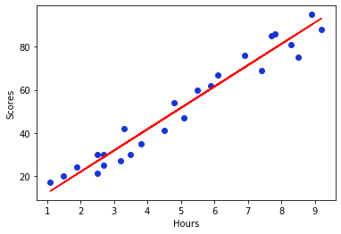

```python
#Plotting the best-fit line
y_pred=reg.predict(x_test)
plt.scatter(X,y,color="#1835d2")
plt.plot(X,Y,color="red")
plt.xlabel("Hours")
plt.ylabel("Scores")
plt.show()
```

## Predicting the scores based on the number of hours given:-

```python
hours=[[9.5]]
pred=reg.predict(hours)
pred
```

```
array([96.16939661])
```

### We can see that the student who studies for 9.5 hours may score 96 marks.

## Model Evaluation:

```python
from sklearn.metrics import mean_squared_error

rmse=np.sqrt(mean_squared_error(y_test,y_pred))
print(rmse)
```

```
4.6474476121003665
```

```python
from sklearn.metrics import r2_score
r2=r2_score(y_test,y_pred)
print(r2)
```

```
0.9454906892105356
```

### This means that 94.54% of score variance is explained by number of hours.if you know the total hurs spent on studies, you will have 94.54% information to make an accurate prediction about how much will the student score.